# Estadistica 2 Trabajo 1 Raul Alberto Perez Agamez

Jhonatan Smith Garcia Muñoz David Armando Blanco Bernal

Mayo, 2022

La base de datos se encuentra conformada por 5 variables, de las cuales se tiene a Y como regresora y a X1,X2,X3 y X4 como variables predictoras. Donde las variables representan lo siguiente:

1. Y: Calificacion global de trabajo realizado por el supervisor
2. X1: Tasa de manejo de quejas de los empleados
3. X2: Tasa de no permision de privilegios especiales
4. X3: Tasa de oportunidad para aprender cosas nuevas
5. X4: Tasa de avance del supervisor a mejires puestos

Tiene la siguiente estructura.

```
##    Y X1 X2 X3 X4
## 1 46 68 75 10 63
## 2 43 55 75 10 57
## 3 53 46 36 58 76
## 4 37 63 41 15 64
## 5 63 67 45 63 71
## 6 73 90 64 67 74
```

# Estimacion del modelo:

Se procede a estimar un modelo de regresion lineal multiple con todas las variables predictoras. Ademas; se tiene en cuenta un analisis de significancia del modelo y de cada una de las variables.

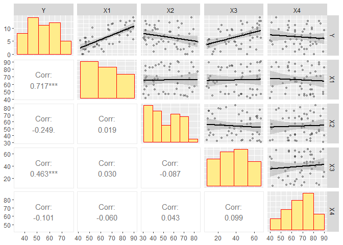

Al observar un grafico de dispersion entre las variables, se observa una tendencia lineal positiva entre X1 con la variable Y. Las demas variables no poseen una tendencia muy marcada aunque, podria interpretarse algo.

X1 y X3 son las variables con mayor correlacion.

*El modelo:*

Se plantea un modelo de RLM para el problema:
$$Y_i = \beta_0 + \beta_1X_{i1} + \beta_2X_{i2} + \cdots+ \beta_4X_{i4} + \varepsilon_i, \quad i = 1, 2, \ldots, 50$$

Que tiene como supuestos lo siguiente:
$$\varepsilon_i \overset{\text{iid}}{\sim} N\left(0,\sigma ^2 \right), \quad i = 1, 2, \ldots, 50$$

También se puede especificar el modelo en términos matriciales, así:
$$\boldsymbol{y} = \boldsymbol{X\beta} + \boldsymbol{\varepsilon} \quad \text{ con }\quad \boldsymbol{\varepsilon}\sim\boldsymbol{N}(\boldsymbol{0}, \sigma^2\boldsymbol{I})$$

**Especificación del modelo de RLM, ANOVA y parámetros estimados**

```
Call:
lm(formula = Y ~ X1 + X2 + X3 + X4)

Residuals:
    Min      1Q  Median      3Q     Max
-11.649  -5.286   1.066   3.456  11.826

Coefficients:
            Estimate Std. Error t value Pr(>|t|)
(Intercept) 23.99789    6.87983   3.488  0.00110 **
X1           0.52747    0.05417   9.738 1.19e-12 ***
X2          -0.15931    0.05223  -3.050  0.00383 **
X3           0.25968    0.04365   5.949 3.71e-07 ***
X4          -0.09286    0.07258  -1.279  0.20732
---
Signif. codes:  0 '***' 0.001 '**' 0.01 '*' 0.05 '.' 0.1 ' ' 1

Residual standard error: 5.856 on 45 degrees of freedom
Multiple R-squared:  0.7674,    Adjusted R-squared:  0.7467
F-statistic: 37.11 on 4 and 45 DF,  p-value: 1.028e-13
```

**El modelo ajustado es:**

$$Y_i = 23.99789 + 0.52747X_{i1} -0.15931X_{i2} + 0.25968 X_{i3} + -0.09286 X_{i4} + \varepsilon_i$$
$$\quad i = 1, 2, \ldots, 50$$

**Prueba de Significancia de la regresión**

Se quiere probar:
$$\begin{aligned}
H_0:&\ \beta_1 = \beta_2 = \cdots = \beta_4 = 0, \quad \text{ vs.}\\
H_1:&\ \text{Algún } \beta_j \neq 0, j = 1, \ldots, 4.
\end{aligned}$$

```
##       Sum_of_Squares DF Mean_Square F_Value     P_value
## Model        5090.64  4   1272.6605 37.1091 1.02755e-13
## Error        1543.28 45     34.2951
```

Para ello se usa la tabla de análisis de varianza. De ella se obtienen los valores del estadístico de prueba $F_0 =37.1091$ y su correspondiente valor-P $\text{vp} = 1.02755e-13$.

Dado estos resultados se concluye que el modelo es significativo, puesto que se rechaza la hipotesis nula a favor de la alterna. Esto es justificado dado que el valor p de la prueba de significancia es menor que un alfa dado (puesto que es casi cero).

Esto implica que, existe almenos una variable que es significativa y que permite explicar la variabilidad de la variable respuesta.

**Cálculo e interpretación del coeficiente de determinación**

Sabemos que $R^2 = \frac{\text{SSR}}{\text{SST}} = 1 - \frac{\text{SSE}}{\text{SST}}$, de manera que se puede calcular de la tabla ANOVA.
$$R^2 = \frac{\text{SSR}}{\text{SST}} = \frac{5090.64}{5090.64 + 1543.28} = 0.7673653$$
Este coeficiente de determinacion permite entender la proporcion de varianza que el modelo está explicando de la variable respuesta. DE esta manera, se entiende que aproximadamente el 76.7% de la varianza total es explicada por el modelo.

En otras palabras y teniendo en cuenta que $R^2_{adj}$ penaliza la varianza a medida que se agregan covariables (factor que no tiene en cuenta por si solo R^2) se prefiere usar para el caso de Regresion Lineal Multiple (RLM) el ajustado.

**Sobre los parametros:**

En el problema planteado, no se especifica las escalas de las variables, si quiera se puede identificar si tienen o no la misma escala. En apariencia, parece que en efecto, son medidas en la misma escala. Sin embargo, se procede a estandarizarlas para asegurar que sea comparable los siguientes analisis.

```
## Coeficientes estimados y Coeficientes estimados estandarizados
```

```
##             Estimacion    Coef.Std
## (Intercept) 23.9978919  0.00000000
## X1           0.5274720  0.70206841
## X2          -0.1593096 -0.22051064
## X3           0.2596755  0.43202199
## X4          -0.0928575 -0.09276353
```

Estos son los coeficientes estandarizados del modelo puesto que, no se podria dictarminar si son comparables debido a su escala.

Segun la magnitud del valor absoluto de los coeficientes estandarizados, se entiende que la vaiable con mayor efecto sobre el modelo es X1 seguido de x3. Este resultado es consistente con el primer analisis descriptivo.

**Prueba de significancia individual de los parametros usando la prueba t**

De la tabla de parámetros estimados, a un nivel de significancia $\alpha = 0.05$ se rechaza $H_0$ si $\left | T_0 \right |> T_\frac{\alpha }{2} ,n-k-1$

Donde k representa el numero de variables, n el numero de la muestra.

Para este caso con la $T_{(1-\frac{0.05}{2},45)}=2.014103$ basta comparar con los datos suministrados en la tabla anterior en la columna de t-values:

```
##
## Call:
## lm(formula = Y ~ X1 + X2 + X3 + X4)
##
## Residuals:
##     Min      1Q  Median      3Q     Max
## -11.649  -5.286   1.066   3.456  11.826
##
## Coefficients:
##             Estimate Std. Error t value Pr(>|t|)
## (Intercept) 23.99789    6.87983   3.488  0.00110 **
## X1           0.52747    0.05417   9.738 1.19e-12 ***
## X2          -0.15931    0.05223  -3.050  0.00383 **
## X3           0.25968    0.04365   5.949 3.71e-07 ***
## X4          -0.09286    0.07258  -1.279  0.20732
## ---
## Signif. codes:  0 '***' 0.001 '**' 0.01 '*' 0.05 '.' 0.1 ' ' 1
##
## Residual standard error: 5.856 on 45 degrees of freedom
## Multiple R-squared:  0.7674, Adjusted R-squared:  0.7467
## F-statistic: 37.11 on 4 and 45 DF,  p-value: 1.028e-13
```

En ese orden de ideas, al analizar la columna “t value” se comparan los que su valor absoluto sea mayor al valor calculado. Segun esto, todas las variables son significativas a exepcion de x4.

Se concluye que los parámetros individuales $\beta_0,\beta_1,\beta_2,\beta_3$ son significativos cada uno en presencia de los demás parámetros; por otro lado, se encuentra que $\beta_4$ no es individualmente significativos en presencia de los demás parámetros.

**Interpretación de los parámetros estimados**

En este caso, el intercepto no tiene interpretabilidad. Por tanto, $\hat{\beta_0}$ no se interpreta

$\hat{\beta_1}$ = 0.52747 indica que por cada unidad de aumento en la tasa de numero de quejas de los empleados la califiacion global del trabajo bien hecho (Y) aumenta en 0.52747 unidades, cuando las demás variables predictoras se mantienen fijas.

$\hat{\beta_2}$ = -0.15931 indica que por cada unidad de aumento en la tasa de no privilegios permitidos en la califiacion global del trabajo bien hecho (Y) aumenta en -0.15931 unidades, cuando las demás variables predictoras se mantienen fijas.

$\hat{\beta_3}$ = 0.25968 indica que por cada unidad de aumento en la tasa de oportunidad de aprender en la califiacion global del trabajo bien hecho (Y) aumenta en 0.25968 unidades, cuando las demás variables predictoras se mantienen fijas.

Esta interpretacion es analoga a todas las demas variables/parametros pero solo se hace con esta por terminos practicos (ademas de que son las significcativas para el modelo FULL)

**Prueba F con sumas de cuadrados extras**

Para esta prueba se elegiran convenientemente los parametros no significativos del modelo, en este caso $\beta_4$. Se plantean las siguientes hipotesis:

$$H_0:\ \hat{\beta_4} = 0\quad \text{ vs. }\quad H_1:\ \text{Algún }\beta_j\neq 0, \ j = 4$$
Esta prueba se desarrolla usando sumas de cuadrados extra y se requiere la tabla de todas las regresiones posibles como se presenta a continuación.

**Modelo FULL**

**Estadistico de prueba F0**

```
## Linear hypothesis test
##
## Hypothesis:
## X4 = 0
##
## Model 1: restricted model
## Model 2: Y ~ X1 + X2 + X3 + X4
##
##   Res.Df    RSS Df Sum of Sq      F Pr(>F)
## 1     46 1599.4
## 2     45 1543.3  1    56.135 1.6368 0.2073
```

El estadistico F tiene valor de 1.6368 y su valor p asociado a dicha prueba es de 0.2073 por tanto no se rechaza la hipotesis nula y se concluye que el parametro $\beta_4$ no es significativo para el modelo.

Se concluye que el conjunto de predictoras simultaneamente no son significativas, en presencia de los demás parámetros lo que implica que la variable X4 no es significativas para explicar la variable respuesta Y. Notese que este resultado coincide con la prueba de significancia individual de los parametros. (Ver summary del modelo en X4)

**Graficos de residuales estudentizados vs valores ajustados**

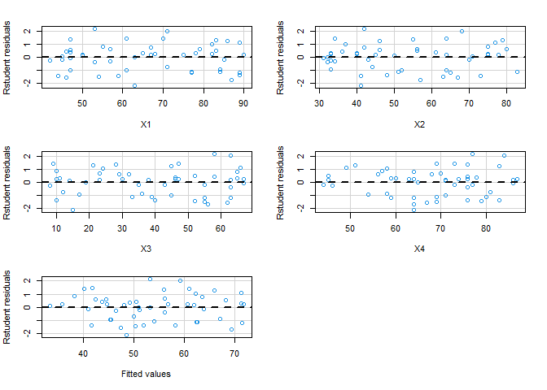

1. Se observa que los datos son aleatorios alrededor de 0, no se identifican patrones dentro de las graficas de estudentizados vs valores ajustados lo que indica que no hay problema de varianza constante.
2. No se evidencian puntos por encima de +- 3 desviaciones. En un principio, parece que no hay evidencia de datos atipicos.
3. En apariencia en el grafico de valores ajustados pareciese haber un punto mas alejado de la nube de puntos. Quizas pueda tratarse de un punto de balanceo.
4. No se observan patrones y se ve aleatoreamente distribuidos. Se asume que no hay carencia de ajuste (Lack of fit) en el modelo.

**Gráfico de normalidad**

$$H_0:\space \varepsilon_i\space \sim N(0,\sigma^2)$$

$$H_1:\space \varepsilon_i\space \nsim N(0,\sigma^2)$$

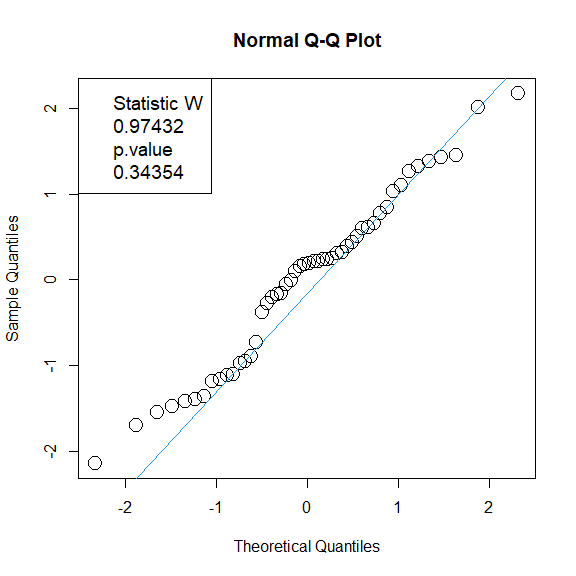

Dado el grafico qqnorm y la prueba de Shaphiro Wilk con el juego de hipotesis ya nombrado, se observa que el valor p es de 0.34 (grande) por tanto no se rechaza la hipotesis nula y se concluye que los residuales distribuyen normal estandar

```
##    Y      ri      ei  se.yhat residuals hii.value
## 1 46  0.2378  0.2403 1.845123    1.3355    0.0993
## 2 43  0.8421  0.8449 2.047569    4.6355    0.1222
## 3 53  0.4405  0.4445 1.852151    2.4695    0.1000
## 4 37 -2.1431 -2.0623 1.545631  -11.6492    0.0697
## 5 63  0.1848  0.1868 1.370624    1.0637    0.0548
## 6 73  0.2164  0.2187 2.063918    1.1986    0.1242
```

Se asume que la observación i es atipica si un ei grande (|ei| > 3) y Se considera potencialmente atipica con ri grande (|ri| > 3).

No se encuentran observaciones atipicas al analizar los datos. Algo consistente con el analisis descriptivo.

NOTA: Para esta seccion, se muestra solo un fragmento de la tabla de datos. De manera unicamente ilustrativa para ejemplificar que se está observando y en que criterios se puede realizar los analisis de interes.

**Observaciones de balanceo**

Se asume que la observación i es un punto de balanceo si hii > 2p/n. En esta práctica tenemos como criterio que: hii > 2(k+1)/n = 2(5/50) = 0.2 De acuerdo a la columna hii.value la observación

```
##     Y      ri      ei  se.yhat residuals hii.value
## 32 77  1.1081  1.1053 2.714468    5.7354    0.2149
## 47 50 -0.2072 -0.2094 2.676427   -1.0909    0.2089
```

Segun esto, las observaciones 32 y 47 son observaciones de balanceo. Ahora, el valor por el cual superan el criterio de la matriz hat no es muy elevado. Es decir, no sobrepasa muy por encima los valores exigidos entonces incluso aqui, se podria analizar dichos puntos para tenerlos presentes y mirar si se descartan o no.

**Observaciones influenciales**

Para identificar estos valores utilizaremos 3 criterios, que son:

- Se dice que la observacion sera influencial si Di > 1.
- una observacion sera influencial si |DFFITS| > 2(p/n)^0.5
- observaciones con un covratio tal que |COVRATIO-1| > 3(p/n) son cadidatas a ser influenciales donde p es el numero de variables

```
##   dfb.1_ dfb.X1 dfb.X2 dfb.X3 dfb.X4 dffit cov.r cook.d   hat
## 1  FALSE  FALSE  FALSE  FALSE  FALSE FALSE FALSE  FALSE FALSE
## 2  FALSE  FALSE  FALSE  FALSE  FALSE FALSE FALSE  FALSE FALSE
## 3  FALSE  FALSE  FALSE  FALSE  FALSE FALSE FALSE  FALSE FALSE
## 4  FALSE  FALSE  FALSE  FALSE  FALSE FALSE FALSE  FALSE FALSE
## 5  FALSE  FALSE  FALSE  FALSE  FALSE FALSE FALSE  FALSE FALSE
## 6  FALSE  FALSE  FALSE  FALSE  FALSE FALSE FALSE  FALSE FALSE
```

NOTA: Con una funcion de usuario, se genera un data frame donde para cada criterio anterior mencionado, evalua cada observacion. Si sobre pasa la cota (es decir, es influencial, de balanceo o a tipico) lo amrca como “TRUE”. Se ilutra, como se puede observar de manera general dicho data frame.

```r
filter(smith, smith$cov.r=="TRUE")
```

```
##    dfb.1_ dfb.X1 dfb.X2 dfb.X3 dfb.X4 dffit cov.r cook.d   hat
## 11  FALSE  FALSE  FALSE  FALSE  FALSE FALSE  TRUE  FALSE FALSE
## 29  FALSE  FALSE  FALSE  FALSE  FALSE FALSE  TRUE  FALSE FALSE
## 47  FALSE  FALSE  FALSE  FALSE  FALSE FALSE  TRUE  FALSE FALSE
```

Por criterio de cov.r se tiene que estas observaciones son observaciones influenciables. Por tanto, se recomienda analizar la observacion 11,29 y 47 para verificarlar, mirar si se pueden remover por algun error a la hora de tomar los datos.

Tenga presente que cada uno de los criterios utilizados tiene metodologias diferentes. Idealmente se espera consistencia entre todos los criteriores entre si. Si un metodo las categoriza como observaciones influenciales y otro no, depende del investigador mirar detenidamente las observaciones y tomar decisiones.

**Gráficas de chequeos y diagnosticos**

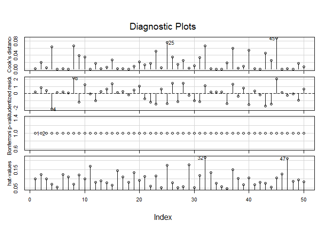

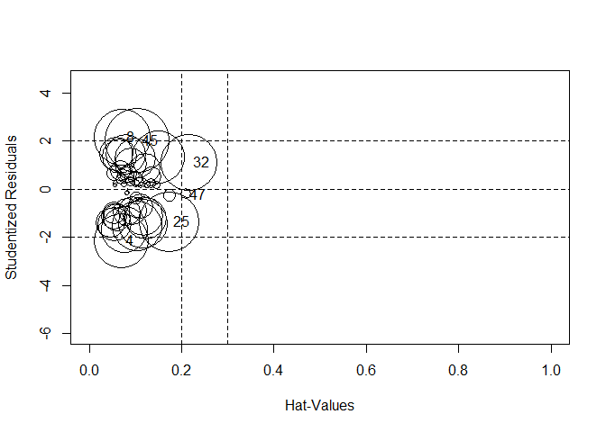

```
##       StudRes        Hat       CookD
## 4  -2.1430808 0.06965944 0.063692125
## 8   2.1804011 0.07067825 0.066745717
## 25 -1.3620716 0.17306036 0.076203904
## 32  1.1080677 0.21485125 0.066858312
## 45  2.0183325 0.10392766 0.088452225
## 47 -0.2071985 0.20887152 0.002316176
```

Dado este grafico, no se encuentran observaciones atipicas ni ninguna otra observacion que presente problemas mas allá de los puntos de balacneo.

**Multicolinealidad para modelo full**

Se debe realizar un analisis de multicolinealidad entre las variables.

**Matriz de correlación de variables predictorias**

```
##             Y          X1          X2          X3          X4
## Y   1.0000000  0.71650650 -0.24864863  0.46319379 -0.10121912
## X1  0.7165065  1.00000000  0.01898235  0.03029248 -0.05968811
## X2 -0.2486486  0.01898235  1.00000000 -0.08673275  0.04306049
## X3  0.4631938  0.03029248 -0.08673275  1.00000000  0.09940430
## X4 -0.1012191 -0.05968811  0.04306049  0.09940430  1.00000000
```

Al observar la matriz de correlacion de las variables, no se percibe una correlacion fuerte entre las predictoras. Entonces se podria sospechar que no hay problemas de multicolinealidad.

**VIF’S** Para analizar problemas de multicolinealidad con los VIF’s, se analiza la siguiente tabla:

```
##       X1       X2       X3       X4
## 1.005544 1.010961 1.020038 1.016934
```

Para VIF’s con valores >10 indica que hay problemas de multicolinealidad. Según este criterio no se detecta problemas de multicolinealidad.

**Proporciones de varianza**

Como en los datos $\beta_0$ no tiene interpretabilidad, se trabaja con los datos centrados. Para ello:

```
##   Val.propio cond.index      Pi.X1     Pi.X2      Pi.X3      Pi.X4
## 1  1.1151558   1.000000 0.02491774 0.1111387 0.45408335 0.29120927
## 2  1.0575866   1.026857 0.23171056 0.3631644 0.05744346 0.28203827
## 3  1.0050077   1.053375 0.60412162 0.2675047 0.06338122 0.05158463
## 4  0.8222499   1.164571 0.13925008 0.2581922 0.42509197 0.37516784
```

Segun el indice de condicion, existe problemas graves de multicolinealidad si dicho indice es mayor de 31. En ninguna de estas variables hay problemas graves de multicolinealidad ni siquiera problemas ligeros. Esto era de esperarse puesto que en la matriz de correlacion se encontró que la covarianza entre las predictoras era muy pequeña.

En terminos generales, no se detecta ningun probelma de multicolinealidad entre las variables predictoras.

**Selección de variables**

comparando todos los posibles modelos y teniendo siempre presente el principio de parsimonia:

- Por criterio de $R^2_{adj}$ y $R^2$, se selecciona el modelo con el valor mas alto
- Por criterio de MSE se selecciona el modelo con menor valor de este estadistico, aunque es equivalente con el anterior (A menor MSE mayor $R^2_{adj}$ y $R^2$ asi que se esperan resultados similares)
- Por criterior de $C_p$ para el valor mas pequeño de dicho estadistico; estadistico que está dado por:

$$C_p=\frac{SSE_p}{MSE(X_1,X_2,...,X_k)}-(n-2p)$$

Donde $SSE_p$ es el SSE del moderlo de regresion con $p-1\leq k$ variables predictoras y el MSE del denominador es el SSE con todas las k predictoras.

```
##   Index N Predictors   R-Square Adj. R-Square Mallow's Cp
## 1     1 1         X1 0.51338156    0.50324367    48.12980
## 3     2 1         X3 0.21454849    0.19818492   105.93504
## 2     3 1         X2 0.06182614    0.04228085   135.47712
## 4     4 1         X4 0.01024531   -0.01037458   145.45474
## 6     5 2      X1 X3 0.70847314    0.69606775    12.39195
## 5     6 2      X1 X2 0.58218121    0.56440168    36.82143
```

Con esto en mente, se seleccionaria acorde a los criterios mencionados; sin embargo, revisar uno a uno los criterios de la tabla puede ser un trabajo poco efectivo y engorroso. Para ello, se apoya en la siguiente grafica:

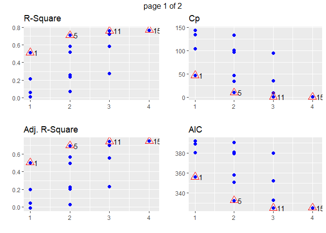

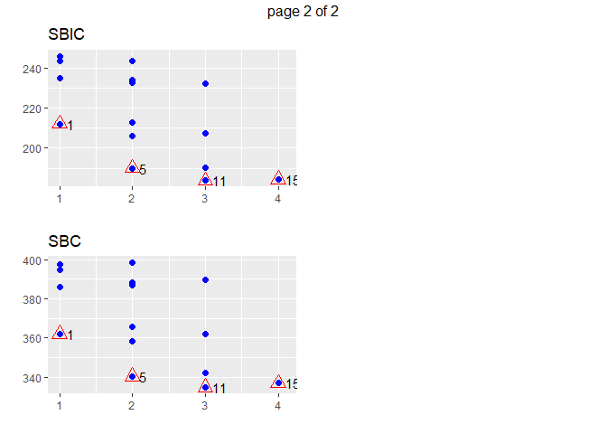

```
##    Index N Predictors  R-Square Adj. R-Square Mallow's Cp
## 11    11 3   X1 X2 X3 0.7589038     0.7431801    4.636818
```

Este modelo tiene a las variables X1,X2 y X3.

**Con las funciones suministradas por el docente**

```
##    k  R_sq adj_R_sq     SSE      Cp Variables_in_model
## 1  1 0.513    0.503 3228.19  48.130                 X1
## 2  1 0.215    0.198 5210.62 105.935                 X3
## 3  1 0.062    0.042 6223.77 135.477                 X2
## 4  1 0.010   -0.010 6565.95 145.455                 X4
## 5  2 0.708    0.696 1933.97  12.392              X1 X3
## 6  2 0.582    0.564 2771.78  36.821              X1 X2
## 7  2 0.517    0.496 3205.44  49.467              X1 X4
## 8  2 0.258    0.227 4920.12  99.464              X2 X3
## 9  2 0.236    0.204 5065.32 103.698              X3 X4
## 10 2 0.070    0.030 6169.32 135.889              X2 X4
## 11 3 0.759    0.743 1599.41   4.637           X1 X2 X3
## 12 3 0.719    0.701 1862.36  12.304           X1 X3 X4
## 13 3 0.584    0.557 2757.13  38.394           X1 X2 X4
## 14 3 0.277    0.230 4795.11  97.819           X2 X3 X4
## 15 4 0.767    0.747 1543.28   5.000        X1 X2 X3 X4
```

La anterior tabla muestra todas las posibles regresiones a realizar con una funcion de usuario. Cabe destacar que para resolver el ejercicio se han usado funciones personalizadas. Sin embargo, esta funcion posee informacion mas concisa y, solo por si acaso, se presenta la tabla de posibles regresiones puesto que un inciso del taller asi lo exige.

**Ajuste del nuevo modelo**

```
##
## Call:
## lm(formula = Y ~ X1 + X2 + X3, data = df)
##
## Residuals:
##      Min       1Q   Median       3Q      Max
## -11.4643  -5.1691   0.6473   4.2920  11.1059
##
## Coefficients:
##             Estimate Std. Error t value Pr(>|t|)
## (Intercept) 17.82509    4.93823   3.610 0.000754 ***
## X1           0.53193    0.05443   9.773 8.41e-13 ***
## X2          -0.16289    0.05251  -3.102 0.003281 **
## X3           0.25377    0.04370   5.807 5.64e-07 ***
## ---
## Signif. codes:  0 '***' 0.001 '**' 0.01 '*' 0.05 '.' 0.1 ' ' 1
##
## Residual standard error: 5.897 on 46 degrees of freedom
## Multiple R-squared:  0.7589, Adjusted R-squared:  0.7432
## F-statistic: 48.27 on 3 and 46 DF,  p-value: 2.976e-14
```

Por esto, se recomienda finalmente este modelo para trabajar.